# Post Goals:

1. Introduction to comparing population means with dependent samples.
2. R method to compare the population mean with dependent samples.

# Introduction to comparing population means with dependent samples.

**The basics**

- This test has two populations with the same numeric variable of interest being observed, but the two observation is for the same sampling unit.
- The two levels can be thought of as two populations.
- The categorical variable is the independent variable.
- The numeric variable we are interested in the comparison, is the response variable, and is commonly called the dependent variable.
- The big difference with this population mean comparison is that the numeric variables are not independent sampling units, rather, they represent two measurements taken from the same sample
- Example: Comparing the exam score of a student before and after a workshop series. The sampling unit is the student, and there are two of the same numeric measurement for the same student.
- Data Organization
  - each instance or row is a sampling unit
  - one column is the response variable from one population (example a time point)
  - second column is the response variable from the second population (example a later time point)
  - Both columns correspond to the same sampling unit
  - the sample mean difference is denoted by 𝑑¯
  - the sample mean difference stndard deviation is denoted by $s_d$
- This test makes inferneces on the difference between the same sampling units population means.
- Assumptions
  - Data comes for a random sample
  - The two measurements are made one each sampling unit
  - The difference in the two populations is normally distributed
- The R programming language will be used to carry out these calculations.
- Hypothesis test:
  - Null Hypothesis. $H_o:\ \mu_D = 0 $
  - Alternative Hypothesis 2 sided: $H_o:\mu_D \neq 0 $
  - Alternative Hypothesis 1 sided lower tail: $H_o:\ \mu_D < 0 $
  - Alternative Hypothesis 1 sided upper tail: $H_o:\ \mu_D > 0 $
- Hypothesis test values:
  - Parameter of interest. $\mu_D$
  - Point estimate. $\bar{d}$
  - Standard error under $H_0$: $s_d/\sqrt{n}$
  - Test statistic. $$t=\frac{\bar d}{s_d/\sqrt{n}}$$
  - Null distribution: student's t distribution
  - Degrees of freedom: $$df=n-1$$
- Confidence intervals:
  - Calculated as $100(1- \alpha)$
  - Two-sides: $$\left(\bar d-t_{df,\alpha/2}\widehat{\mathsf{SE}},\bar d+t_{df,\alpha/2}\widehat{\mathsf{SE}}\right)$$
  - Upper one-sided: $$\left(-\infty, \bar d+t_{df,\alpha}\widehat{\mathsf{SE}}\right)$$
  - Lower one-sided: $$\left(\bar d-t_{df,\alpha}\widehat{\mathsf{SE}},\infty\right)$$

# R method to compare the population mean with dependent samples.

**The code**

- `t.test(before, after, paired=TRUE, alt=TYPE, conf.level=CL)`
- Example: cholesterol measurements are obtained from patients before and after a treatment.
- Did the treatment reduce the cholesterol.

## Load and inspect data

```r
cholesterol <- read.csv("data/cholesterol.paired.csv")
attach(cholesterol)
str(cholesterol)
```

```
'data.frame':	15 obs. of  3 variables:
 $ subj  : int  1 2 3 4 5 6 7 8 9 10 ...
 $ before: int  265 240 258 295 251 245 287 314 260 279 ...
 $ after : int  258 234 245 286 239 235 280 301 248 268 ...
```

```r
#view data
cholesterol
```

A data.frame: 15 × 3

| subj <int> | before <int> | after <int> |
| --- | --- | --- |
| 1 | 265 | 258 |
| 2 | 240 | 234 |
| 3 | 258 | 245 |
| 4 | 295 | 286 |
| 5 | 251 | 239 |
| 6 | 245 | 235 |
| 7 | 287 | 280 |
| 8 | 314 | 301 |
| 9 | 260 | 248 |
| 10 | 279 | 268 |
| 11 | 283 | 264 |
| 12 | 240 | 228 |
| 13 | 238 | 234 |
| 14 | 225 | 216 |
| 15 | 247 | 237 |

## Calculate parameters, test statistic, and p-values

```r
diff <- before-after
dbar <- mean(diff); dbar
s.d <- sd(diff); s.d
n <- length(diff); n
df <- n -1; df
t.crit <- qt(0.05, df, lower.tail=FALSE); t.crit
t.stat <- dbar/(s.d/sqrt(n)); t.stat
p.value <- pt(t.stat, df, lower.tail=FALSE); p.value
```

10.2666666666667

3.61478445646026

15

14

1.76131013577489

11

1.41689849994331e-08

# Confirm the difference in the data is normally distributed

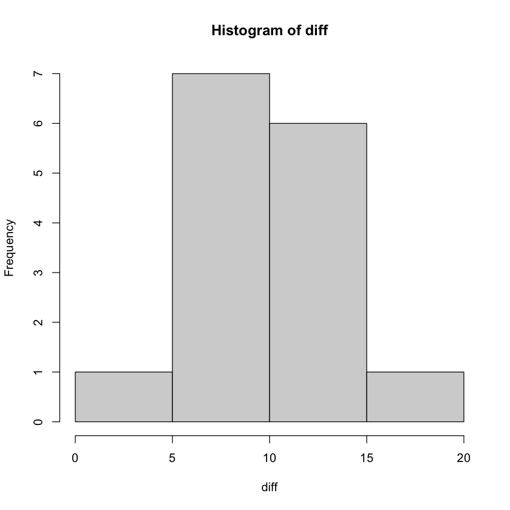

```r
hist(diff)
```

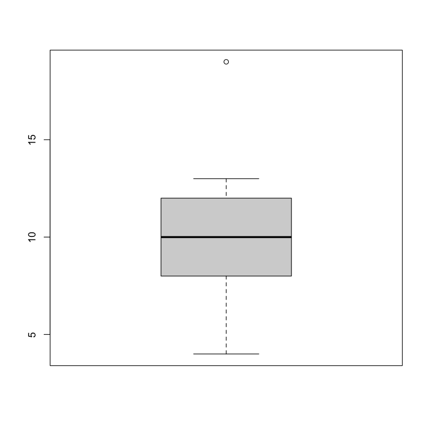

```r
boxplot(diff)
```

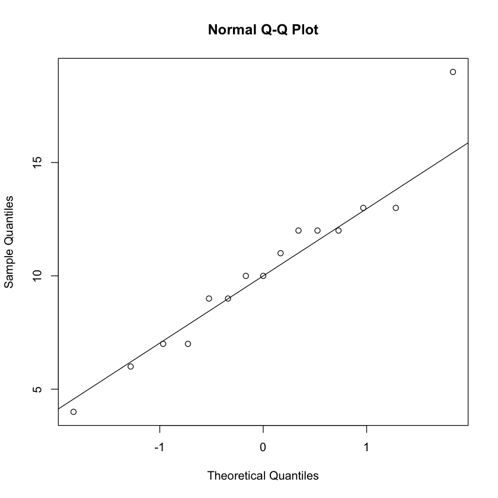

```r
qqnorm(diff); qqline(diff)
```

## Manual Example Result Reject $H_0$ The difference between the two dependent sample populations appear normally distributed and the p value is less than the alpha level, there is a difference between samples.

# Use R method `t.test(before, after, paired=TRUE, alt='g')`

```r
t.test(cholesterol$before, cholesterol$after, paired=TRUE, alt='g')
```

```
	Paired t-test

data:  cholesterol$before and cholesterol$after
t = 11, df = 14, p-value = 1.417e-08
alternative hypothesis: true difference in means is greater than 0
95 percent confidence interval:
 8.622777      Inf
sample estimates:
mean of the differences
               10.26667
```

## R Programming Example Result Reject $H_0$ The p value is less than the alpha level, there is a difference between samples and the confidence interval at 95% is (8.6228, infinity).